# Titanic 2

## Investigating the Titanic Dataset

#### 7/19/2017

## Questions

#### I was curious about how the different demographics such as sex, ticket class, and the location that the passenger embarked at affected the survival rate based on the data that was given. What was the overall survival rate among the passangers? What was the survival rate among male and female? How does the survival rate look like among the different ticket classes? What were the survival rates by ticket class and sex?

```python
import numpy as np
import pandas as pd
```

```python
import matplotlib.pyplot as plt
%matplotlib inline
```

```python
titanic = pd.read_csv('https://d17h27t6h515a5.cloudfront.net/topher/2016/September/57e9a84c_titanic-data/titanic-data.csv')
titanicDF = pd.DataFrame(titanic)
```

```python
titanicDF.head()
```

|  | PassengerId | Survived | Pclass | Name | Sex | Age | SibSp | Parch | Ticket | Fare | Cabin | Embarked |
| --- | --- | --- | --- | --- | --- | --- | --- | --- | --- | --- | --- | --- |
| 0 | 1 | 0 | 3 | Braund, Mr. Owen Harris | male | 22.0 | 1 | 0 | A/5 21171 | 7.2500 | NaN | S |
| 1 | 2 | 1 | 1 | Cumings, Mrs. John Bradley (Florence Briggs Th... | female | 38.0 | 1 | 0 | PC 17599 | 71.2833 | C85 | C |
| 2 | 3 | 1 | 3 | Heikkinen, Miss. Laina | female | 26.0 | 0 | 0 | STON/O2. 3101282 | 7.9250 | NaN | S |
| 3 | 4 | 1 | 1 | Futrelle, Mrs. Jacques Heath (Lily May Peel) | female | 35.0 | 1 | 0 | 113803 | 53.1000 | C123 | S |
| 4 | 5 | 0 | 3 | Allen, Mr. William Henry | male | 35.0 | 0 | 0 | 373450 | 8.0500 | NaN | S |

```python
titanicDF.info()
```

```
<class 'pandas.core.frame.DataFrame'>
RangeIndex: 891 entries, 0 to 890
Data columns (total 12 columns):
PassengerId    891 non-null int64
Survived       891 non-null int64
Pclass         891 non-null int64
Name           891 non-null object
Sex            891 non-null object
Age            714 non-null float64
SibSp          891 non-null int64
Parch          891 non-null int64
Ticket         891 non-null object
Fare           891 non-null float64
Cabin          204 non-null object
Embarked       889 non-null object
dtypes: float64(2), int64(5), object(5)
memory usage: 83.6+ KB
```

## Data Wrangling

### Creating a dictionary to correspond to the social economic class as described in the notes section

```python
'''pclass Ticket class
pclass: A proxy for socio-economic status (SES)'''
TicketClass = {
    1  : 'Upper',
    2  : 'Middle',
    3  : 'Lower'
}
```

### Modifying the Pclass to display the actual ticket class:

```python
titanicDF['Pclass'] = titanicDF['Pclass'].map(TicketClass)
```

```python
titanicDF.rename(columns={'Pclass': 'Ticket Class'}, inplace=True)
```

```python
titanicDF.head()
```

|  | PassengerId | Survived | Ticket Class | Name | Sex | Age | SibSp | Parch | Ticket | Fare | Cabin | Embarked |
| --- | --- | --- | --- | --- | --- | --- | --- | --- | --- | --- | --- | --- |
| 0 | 1 | 0 | Lower | Braund, Mr. Owen Harris | male | 22.0 | 1 | 0 | A/5 21171 | 7.2500 | NaN | S |
| 1 | 2 | 1 | Upper | Cumings, Mrs. John Bradley (Florence Briggs Th... | female | 38.0 | 1 | 0 | PC 17599 | 71.2833 | C85 | C |
| 2 | 3 | 1 | Lower | Heikkinen, Miss. Laina | female | 26.0 | 0 | 0 | STON/O2. 3101282 | 7.9250 | NaN | S |
| 3 | 4 | 1 | Upper | Futrelle, Mrs. Jacques Heath (Lily May Peel) | female | 35.0 | 1 | 0 | 113803 | 53.1000 | C123 | S |
| 4 | 5 | 0 | Lower | Allen, Mr. William Henry | male | 35.0 | 0 | 0 | 373450 | 8.0500 | NaN | S |

### Creating a dictionary for the names of the cities:

```python
EmbarkedLocation = {
    'C'  : 'Cherbourg',
    'Q'  : 'Queenstown',
    'S'  : 'Southampton'
}
```

### Modifying the Embarked locations to display the actual locations:

```python
titanicDF['Embarked'] = titanicDF['Embarked'].map(EmbarkedLocation)
titanicDF.head()
```

|  | PassengerId | Survived | Ticket Class | Name | Sex | Age | SibSp | Parch | Ticket | Fare | Cabin | Embarked |
| --- | --- | --- | --- | --- | --- | --- | --- | --- | --- | --- | --- | --- |
| 0 | 1 | 0 | Lower | Braund, Mr. Owen Harris | male | 22.0 | 1 | 0 | A/5 21171 | 7.2500 | NaN | Southampton |
| 1 | 2 | 1 | Upper | Cumings, Mrs. John Bradley (Florence Briggs Th... | female | 38.0 | 1 | 0 | PC 17599 | 71.2833 | C85 | Cherbourg |
| 2 | 3 | 1 | Lower | Heikkinen, Miss. Laina | female | 26.0 | 0 | 0 | STON/O2. 3101282 | 7.9250 | NaN | Southampton |
| 3 | 4 | 1 | Upper | Futrelle, Mrs. Jacques Heath (Lily May Peel) | female | 35.0 | 1 | 0 | 113803 | 53.1000 | C123 | Southampton |
| 4 | 5 | 0 | Lower | Allen, Mr. William Henry | male | 35.0 | 0 | 0 | 373450 | 8.0500 | NaN | Southampton |

### Creating a dictionary for no and yes that corresponds to 0 and 1:

```python
SurvivalYesNo = {
    0  : 'No',
    1  : 'Yes'
}
```

### Modifying the Survived column to read either yes or no instead of the default 0 or 1:

```python
titanicDF['Survived'] = titanicDF['Survived'].map(SurvivalYesNo)
titanicDF.head()
```

|  | PassengerId | Survived | Ticket Class | Name | Sex | Age | SibSp | Parch | Ticket | Fare | Cabin | Embarked |
| --- | --- | --- | --- | --- | --- | --- | --- | --- | --- | --- | --- | --- |
| 0 | 1 | No | Lower | Braund, Mr. Owen Harris | male | 22.0 | 1 | 0 | A/5 21171 | 7.2500 | NaN | Southampton |
| 1 | 2 | Yes | Upper | Cumings, Mrs. John Bradley (Florence Briggs Th... | female | 38.0 | 1 | 0 | PC 17599 | 71.2833 | C85 | Cherbourg |
| 2 | 3 | Yes | Lower | Heikkinen, Miss. Laina | female | 26.0 | 0 | 0 | STON/O2. 3101282 | 7.9250 | NaN | Southampton |
| 3 | 4 | Yes | Upper | Futrelle, Mrs. Jacques Heath (Lily May Peel) | female | 35.0 | 1 | 0 | 113803 | 53.1000 | C123 | Southampton |
| 4 | 5 | No | Lower | Allen, Mr. William Henry | male | 35.0 | 0 | 0 | 373450 | 8.0500 | NaN | Southampton |

### What was the overall survival rate among the passangers?

```python
overallSurvival = 100 * titanicDF['Survived'].value_counts(normalize=True)
overallSurvival
```

```
No     61.616162
Yes    38.383838
Name: Survived, dtype: float64
```

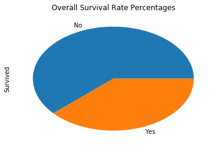

```python
overallSurvival.plot.pie().set_title('Overall Survival Rate Percentages')
```

##### 61.62% did not survive and 38.38% did survive based on the limited data set that we had access to.

### What was the survival rate among male and female?

```python
groupby_Sex = titanicDF['Survived'].groupby(titanicDF['Sex'])
groupby_Sex
```

```
<pandas.core.groupby.SeriesGroupBy object at 0x000002D1D11AB898>
```

```python
groupby_Sex.value_counts()
```

```
Sex     Survived
female  Yes         233
        No           81
male    No          468
        Yes         109
Name: Survived, dtype: int64
```

### The number of female and male that survived:

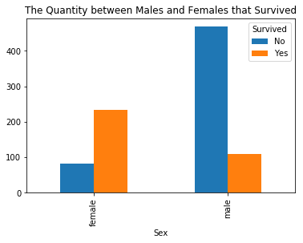

```python
groupby_Sex.value_counts().unstack().plot.bar().set_title('The Quantity between Males and Females that Survived')
```

### What were the survival rate percentages among males and females?

### Which sex had greater survival rate?

```python
survivalMF = 100 * groupby_Sex.value_counts(normalize = True)
survivalMF
```

```
Sex     Survived
female  Yes         74.203822
        No          25.796178
male    No          81.109185
        Yes         18.890815
Name: Survived, dtype: float64
```

### Survival Rates by Sex:

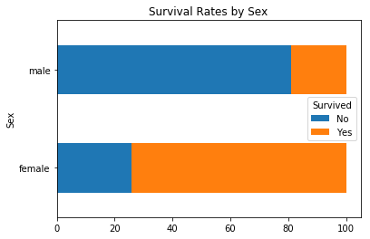

```python
survivalMF.unstack().plot.barh(stacked = True).set_title('Survival Rates by Sex')
```

#### Females had 74.20% survival compared to 18.90% for male passengers.

### How does the survival rate look among the different ticket classes?

```python
groupby_Ticket_Class = titanicDF['Survived'].groupby(titanicDF['Ticket Class'])
groupby_Ticket_Class.value_counts()
```

```
Ticket Class  Survived
Lower         No          372
              Yes         119
Middle        No           97
              Yes          87
Upper         Yes         136
              No           80
Name: Survived, dtype: int64
```

### Survival Quantity based on the Ticket Class:

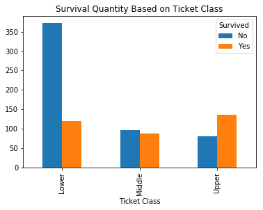

```python
groupby_Ticket_Class.value_counts().unstack().plot.bar().set_title('Survival Quantity Based on Ticket Class')
```

#### Based on the data on hand, the Upper Ticket Class section had the most amount of people that survived compared to the Lower Ticket Class had the largest amount of people not surviving.

### Percentage of survival rate by Ticket Class:

```python
100 * groupby_Ticket_Class.value_counts(normalize = True)
```

```
Ticket Class  Survived
Lower         No          75.763747
              Yes         24.236253
Middle        No          52.717391
              Yes         47.282609
Upper         Yes         62.962963
              No          37.037037
Name: Survived, dtype: float64
```

### How does survival rates look like by embarking location?

```python
groupby_Embarked = titanicDF['Survived'].groupby(titanicDF['Embarked'])
groupby_Embarked.value_counts()
```

```
Embarked     Survived
Cherbourg    Yes          93
             No           75
Queenstown   No           47
             Yes          30
Southampton  No          427
             Yes         217
Name: Survived, dtype: int64
```

### The Number of People that Survived based on their Embarked Location:

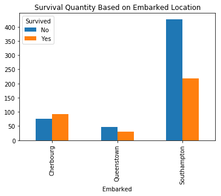

```python
groupby_Embarked.value_counts().unstack().plot.bar().set_title('Survival Quantity Based on Embarked Location')
```

#### With the available data, Southampton had the highest amount of people that did not survive.

### Survival rate percentages by Embarked location:

```python
100 * groupby_Embarked.value_counts(normalize = True)
```

```
Embarked     Survived
Cherbourg    Yes         55.357143
             No          44.642857
Queenstown   No          61.038961
             Yes         38.961039
Southampton  No          66.304348
             Yes         33.695652
Name: Survived, dtype: float64
```

#### Based on available data, people that came from Cherbourg had the best percentage rate of survival and people from Southampton had the least favorable percentage rate of survival.

### What are the survival rates by ticket class and sex?

```python
groupby_two_factors = titanicDF['Survived'].groupby([titanicDF['Ticket Class'], titanicDF['Sex']])
groupby_two_factors.value_counts()
```

```
Ticket Class  Sex     Survived
Lower         female  No           72
                      Yes          72
              male    No          300
                      Yes          47
Middle        female  Yes          70
                      No            6
              male    No           91
                      Yes          17
Upper         female  Yes          91
                      No            3
              male    No           77
                      Yes          45
Name: Survived, dtype: int64
```

### Quantity of survivors broken down by sex and ticket class:

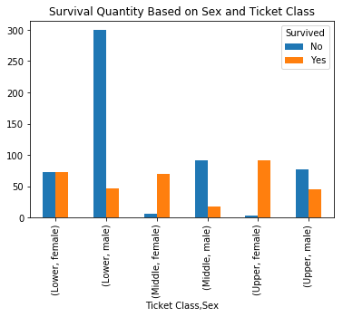

```python
groupby_two_factors.value_counts().unstack().plot.bar().set_title('Survival Quantity Based on Sex and Ticket Class');
```

#### The Upper Ticket Class female had the most amount of people surviving based on the available data.The Lower Ticket Class male had the most amount of people that did not survive based on the data that we have.

### Survival rate Percentages by ticket class and sex of the passengers:

```python
TwoFactorPercentage = 100 * groupby_two_factors.value_counts(normalize=True)
TwoFactorPercentage
```

```
Ticket Class  Sex     Survived
Lower         female  No          50.000000
                      Yes         50.000000
              male    No          86.455331
                      Yes         13.544669
Middle        female  Yes         92.105263
                      No           7.894737
              male    No          84.259259
                      Yes         15.740741
Upper         female  Yes         96.808511
                      No           3.191489
              male    No          63.114754
                      Yes         36.885246
Name: Survived, dtype: float64
```

## Conclusion:

#### The data on hand only provided a glimpse of the survival rates among the different passengers on board the Titanic. The sample that was made available only had 891 instances out of the overall population of 2224. As a result, we can not conclude that there's a direct causation out of any perceived correlations. This dataset leaves me wanting to have access to a complete portion to further investigate the different variables that I was interested in. It leaves me wondering if females continued having a larger percentage of survival and whether or not the Upper Ticket Class Section continued having a better rate of survival.